# Optimal Treatment Analysis

## Outcome Variable

**Outcome Variable:** haz

## Predictor Variables

**Intervention Variable:** mbmi

**Adjustment Set:**

- arm
- W_mage
- meducyrs
- feducyrs
- hhwealth_quart
- brthmon
- W_parity
- impfloor
- impsan
- safeh20
- delta_W_mage
- delta_meducyrs
- delta_feducyrs
- delta_hhwealth_quart
- delta_brthmon
- delta_W_parity
- delta_impfloor
- delta_impsan
- delta_safeh20

## Stratifying Variables

The analysis was stratified on these variable(s):

- agecat
- studyid
- country

## Data Summary

| agecat | studyid | country | mbmi | n_cell | n |
| --- | --- | --- | --- | --- | --- |
| Birth | ki0047075b-MAL-ED | BANGLADESH | Normal weight | 194 | 222 |
| Birth | ki0047075b-MAL-ED | BANGLADESH | Underweight | 28 | 222 |
| Birth | ki0047075b-MAL-ED | BRAZIL | Normal weight | 59 | 64 |
| Birth | ki0047075b-MAL-ED | BRAZIL | Underweight | 5 | 64 |
| Birth | ki0047075b-MAL-ED | INDIA | Normal weight | 35 | 43 |
| Birth | ki0047075b-MAL-ED | INDIA | Underweight | 8 | 43 |
| Birth | ki0047075b-MAL-ED | NEPAL | Normal weight | 27 | 27 |
| Birth | ki0047075b-MAL-ED | NEPAL | Underweight | 0 | 27 |
| Birth | ki0047075b-MAL-ED | PERU | Normal weight | 221 | 226 |
| Birth | ki0047075b-MAL-ED | PERU | Underweight | 5 | 226 |
| Birth | ki0047075b-MAL-ED | SOUTH AFRICA | Normal weight | 98 | 101 |
| Birth | ki0047075b-MAL-ED | SOUTH AFRICA | Underweight | 3 | 101 |
| Birth | ki0047075b-MAL-ED | TANZANIA, UNITED REPUBLIC OF | Normal weight | 115 | 122 |
| Birth | ki0047075b-MAL-ED | TANZANIA, UNITED REPUBLIC OF | Underweight | 7 | 122 |
| Birth | ki1000304b-SAS-CompFeed | INDIA | Normal weight | 830 | 1135 |
| Birth | ki1000304b-SAS-CompFeed | INDIA | Underweight | 305 | 1135 |
| Birth | ki1017093-NIH-Birth | BANGLADESH | Normal weight | 506 | 608 |
| Birth | ki1017093-NIH-Birth | BANGLADESH | Underweight | 102 | 608 |
| Birth | ki1017093b-PROVIDE | BANGLADESH | Normal weight | 418 | 517 |
| Birth | ki1017093b-PROVIDE | BANGLADESH | Underweight | 99 | 517 |
| Birth | ki1017093c-NIH-Crypto | BANGLADESH | Normal weight | 663 | 729 |
| Birth | ki1017093c-NIH-Crypto | BANGLADESH | Underweight | 66 | 729 |
| Birth | ki1119695-PROBIT | BELARUS | Normal weight | 13200 | 13723 |
| Birth | ki1119695-PROBIT | BELARUS | Underweight | 523 | 13723 |
| Birth | ki1126311-ZVITAMBO | ZIMBABWE | Normal weight | 9162 | 9672 |
| Birth | ki1126311-ZVITAMBO | ZIMBABWE | Underweight | 510 | 9672 |
| Birth | kiGH5241-JiVitA-3 | BANGLADESH | Normal weight | 13720 | 22355 |
| Birth | kiGH5241-JiVitA-3 | BANGLADESH | Underweight | 8635 | 22355 |
| 6 months | ki0047075b-MAL-ED | BANGLADESH | Normal weight | 209 | 241 |
| 6 months | ki0047075b-MAL-ED | BANGLADESH | Underweight | 32 | 241 |

[output cut: 60 more lines]

The following strata were considered:

- agecat: 24 months, studyid: ki0047075b-MAL-ED, country: BANGLADESH
- agecat: 24 months, studyid: ki0047075b-MAL-ED, country: BRAZIL
- agecat: 24 months, studyid: ki0047075b-MAL-ED, country: INDIA
- agecat: 24 months, studyid: ki0047075b-MAL-ED, country: NEPAL
- agecat: 24 months, studyid: ki0047075b-MAL-ED, country: PERU
- agecat: 24 months, studyid: ki0047075b-MAL-ED, country: SOUTH AFRICA
- agecat: 24 months, studyid: ki0047075b-MAL-ED, country: TANZANIA, UNITED REPUBLIC OF
- agecat: 24 months, studyid: ki1017093-NIH-Birth, country: BANGLADESH
- agecat: 24 months, studyid: ki1017093b-PROVIDE, country: BANGLADESH
- agecat: 24 months, studyid: ki1017093c-NIH-Crypto, country: BANGLADESH
- agecat: 24 months, studyid: ki1066203-TanzaniaChild2, country: TANZANIA, UNITED REPUBLIC OF
- agecat: 24 months, studyid: ki1119695-PROBIT, country: BELARUS
- agecat: 24 months, studyid: ki1126311-ZVITAMBO, country: ZIMBABWE
- agecat: 24 months, studyid: ki1148112-LCNI-5, country: MALAWI
- agecat: 24 months, studyid: kiGH5241-JiVitA-3, country: BANGLADESH
- agecat: 6 months, studyid: ki0047075b-MAL-ED, country: BANGLADESH
- agecat: 6 months, studyid: ki0047075b-MAL-ED, country: BRAZIL
- agecat: 6 months, studyid: ki0047075b-MAL-ED, country: INDIA
- agecat: 6 months, studyid: ki0047075b-MAL-ED, country: NEPAL
- agecat: 6 months, studyid: ki0047075b-MAL-ED, country: PERU
- agecat: 6 months, studyid: ki0047075b-MAL-ED, country: SOUTH AFRICA
- agecat: 6 months, studyid: ki0047075b-MAL-ED, country: TANZANIA, UNITED REPUBLIC OF
- agecat: 6 months, studyid: ki1000304b-SAS-CompFeed, country: INDIA
- agecat: 6 months, studyid: ki1017093-NIH-Birth, country: BANGLADESH
- agecat: 6 months, studyid: ki1017093b-PROVIDE, country: BANGLADESH
- agecat: 6 months, studyid: ki1017093c-NIH-Crypto, country: BANGLADESH
- agecat: 6 months, studyid: ki1066203-TanzaniaChild2, country: TANZANIA, UNITED REPUBLIC OF
- agecat: 6 months, studyid: ki1119695-PROBIT, country: BELARUS
- agecat: 6 months, studyid: ki1126311-ZVITAMBO, country: ZIMBABWE
- agecat: 6 months, studyid: ki1148112-LCNI-5, country: MALAWI
- agecat: 6 months, studyid: kiGH5241-JiVitA-3, country: BANGLADESH
- agecat: Birth, studyid: ki0047075b-MAL-ED, country: BANGLADESH
- agecat: Birth, studyid: ki0047075b-MAL-ED, country: BRAZIL
- agecat: Birth, studyid: ki0047075b-MAL-ED, country: INDIA
- agecat: Birth, studyid: ki0047075b-MAL-ED, country: NEPAL
- agecat: Birth, studyid: ki0047075b-MAL-ED, country: PERU
- agecat: Birth, studyid: ki0047075b-MAL-ED, country: SOUTH AFRICA
- agecat: Birth, studyid: ki0047075b-MAL-ED, country: TANZANIA, UNITED REPUBLIC OF
- agecat: Birth, studyid: ki1000304b-SAS-CompFeed, country: INDIA
- agecat: Birth, studyid: ki1017093-NIH-Birth, country: BANGLADESH
- agecat: Birth, studyid: ki1017093b-PROVIDE, country: BANGLADESH
- agecat: Birth, studyid: ki1017093c-NIH-Crypto, country: BANGLADESH
- agecat: Birth, studyid: ki1119695-PROBIT, country: BELARUS
- agecat: Birth, studyid: ki1126311-ZVITAMBO, country: ZIMBABWE
- agecat: Birth, studyid: kiGH5241-JiVitA-3, country: BANGLADESH

### Dropped Strata

Some strata were dropped due to rare outcomes:

- agecat: Birth, studyid: ki0047075b-MAL-ED, country: NEPAL
- agecat: Birth, studyid: ki0047075b-MAL-ED, country: SOUTH AFRICA
- agecat: 6 months, studyid: ki0047075b-MAL-ED, country: NEPAL
- agecat: 24 months, studyid: ki0047075b-MAL-ED, country: NEPAL
- agecat: 24 months, studyid: ki0047075b-MAL-ED, country: PERU
- agecat: 24 months, studyid: ki1066203-TanzaniaChild2, country: TANZANIA, UNITED REPUBLIC OF

## Methods Detail

We’re interested in the causal parameters $E[Y_a]$ for all values of $a \in \mathcal{A}$. These parameters represent the mean outcome if, possibly contrary to fact, we intervened to set all units to have $A=a$. Under the randomization and positivity assumptions, these are identified by the statistical parameters $\psi_a=E_W[E_{Y|A,W}(Y|A=a,W)]$. In addition, we’re interested in the mean of $Y$, $E[Y]$ under no intervention (the observed mean). We will estimate these parameters by using SuperLearner to fit the relevant likelihood factors – $E_{Y|A,W}(Y|A=a,W)$ and $p(A=a|W)$, and then updating our likelihood fit using a joint TMLE.

For unadjusted analyses ($W=\{\}$), initial likelihoods were estimated using Lrnr_glm to estimate the simple $E(Y|A)$ and Lrnr_mean to estimate $p(A)$. For adjusted analyses, a small library containing Lrnr_glmnet, Lrnr_xgboost, and Lrnr_mean was used.

Having estimated these parameters, we will then use the delta method to estimate relative risks and attributable risks relative to a prespecified baseline level of $A$.

# Results Detail

## Results Plots

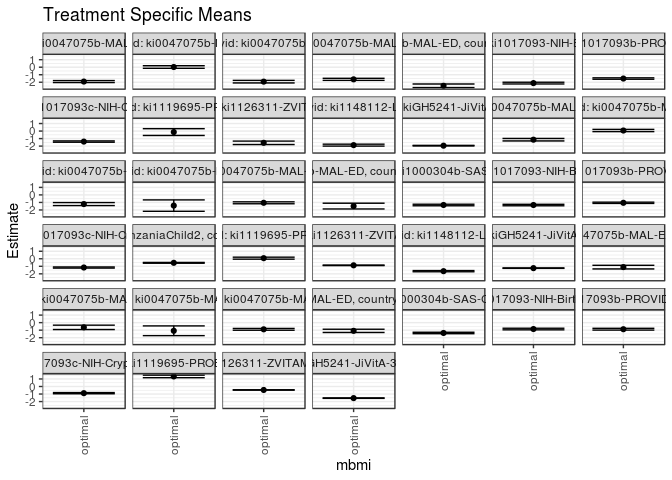

## Results Table

### Parameter: TSM

| agecat | studyid | country | intervention_level | baseline_level | estimate | ci_lower | ci_upper |
| --- | --- | --- | --- | --- | --- | --- | --- |
| Birth | ki0047075b-MAL-ED | BANGLADESH | optimal | observed | -1.1063552 | -1.3488965 | -0.8638140 |
| Birth | ki0047075b-MAL-ED | BRAZIL | optimal | observed | -0.6246218 | -0.9160924 | -0.3331512 |
| Birth | ki0047075b-MAL-ED | INDIA | optimal | observed | -1.0813323 | -1.7285801 | -0.4340845 |
| Birth | ki0047075b-MAL-ED | PERU | optimal | observed | -0.8869390 | -1.0065491 | -0.7673289 |
| Birth | ki0047075b-MAL-ED | TANZANIA, UNITED REPUBLIC OF | optimal | observed | -1.0903146 | -1.3047115 | -0.8759177 |
| Birth | ki1000304b-SAS-CompFeed | INDIA | optimal | observed | -1.3712738 | -1.4649746 | -1.2775729 |
| Birth | ki1017093-NIH-Birth | BANGLADESH | optimal | observed | -0.8506269 | -0.9566817 | -0.7445722 |
| Birth | ki1017093b-PROVIDE | BANGLADESH | optimal | observed | -0.8736249 | -0.9922737 | -0.7549761 |
| Birth | ki1017093c-NIH-Crypto | BANGLADESH | optimal | observed | -0.8855294 | -0.9620189 | -0.8090399 |
| Birth | ki1119695-PROBIT | BELARUS | optimal | observed | 1.3372707 | 1.1706132 | 1.5039282 |
| Birth | ki1126311-ZVITAMBO | ZIMBABWE | optimal | observed | -0.4602046 | -0.4852807 | -0.4351285 |
| Birth | kiGH5241-JiVitA-3 | BANGLADESH | optimal | observed | -1.5432866 | -1.5711322 | -1.5154409 |
| 6 months | ki0047075b-MAL-ED | BANGLADESH | optimal | observed | -1.1472223 | -1.3108839 | -0.9835607 |
| 6 months | ki0047075b-MAL-ED | BRAZIL | optimal | observed | 0.0711041 | -0.0779686 | 0.2201767 |
| 6 months | ki0047075b-MAL-ED | INDIA | optimal | observed | -1.2141788 | -1.4150373 | -1.0133204 |
| 6 months | ki0047075b-MAL-ED | PERU | optimal | observed | -1.4166963 | -2.1740014 | -0.6593911 |
| 6 months | ki0047075b-MAL-ED | SOUTH AFRICA | optimal | observed | -1.0465890 | -1.1775777 | -0.9156004 |
| 6 months | ki0047075b-MAL-ED | TANZANIA, UNITED REPUBLIC OF | optimal | observed | -1.4810293 | -1.8634592 | -1.0985994 |
| 6 months | ki1000304b-SAS-CompFeed | INDIA | optimal | observed | -1.3383289 | -1.4388973 | -1.2377606 |
| 6 months | ki1017093-NIH-Birth | BANGLADESH | optimal | observed | -1.3426829 | -1.4383203 | -1.2470455 |
| 6 months | ki1017093b-PROVIDE | BANGLADESH | optimal | observed | -1.0473275 | -1.1314177 | -0.9632374 |
| 6 months | ki1017093c-NIH-Crypto | BANGLADESH | optimal | observed | -1.1591333 | -1.2332933 | -1.0849732 |
| 6 months | ki1066203-TanzaniaChild2 | TANZANIA, UNITED REPUBLIC OF | optimal | observed | -0.5358103 | -0.5862527 | -0.4853680 |
| 6 months | ki1119695-PROBIT | BELARUS | optimal | observed | 0.0810494 | -0.0530911 | 0.2151898 |
| 6 months | ki1126311-ZVITAMBO | ZIMBABWE | optimal | observed | -0.8686756 | -0.8968725 | -0.8404786 |
| 6 months | ki1148112-LCNI-5 | MALAWI | optimal | observed | -1.6461697 | -1.7245301 | -1.5678094 |
| 6 months | kiGH5241-JiVitA-3 | BANGLADESH | optimal | observed | -1.2418276 | -1.2725334 | -1.2111219 |
| 24 months | ki0047075b-MAL-ED | BANGLADESH | optimal | observed | -1.9080731 | -2.0401860 | -1.7759602 |
| 24 months | ki0047075b-MAL-ED | BRAZIL | optimal | observed | 0.0251524 | -0.1449254 | 0.1952301 |
| 24 months | ki0047075b-MAL-ED | INDIA | optimal | observed | -1.9188856 | -2.0900424 | -1.7477288 |
| 24 months | ki0047075b-MAL-ED | SOUTH AFRICA | optimal | observed | -1.6130934 | -1.7508390 | -1.4753478 |
| 24 months | ki0047075b-MAL-ED | TANZANIA, UNITED REPUBLIC OF | optimal | observed | -2.4701885 | -2.7080301 | -2.2323469 |
| 24 months | ki1017093-NIH-Birth | BANGLADESH | optimal | observed | -2.1121196 | -2.2253656 | -1.9988736 |
| 24 months | ki1017093b-PROVIDE | BANGLADESH | optimal | observed | -1.5071115 | -1.6014278 | -1.4127952 |
| 24 months | ki1017093c-NIH-Crypto | BANGLADESH | optimal | observed | -1.3989618 | -1.4854266 | -1.3124971 |
| 24 months | ki1119695-PROBIT | BELARUS | optimal | observed | -0.1330740 | -0.5837649 | 0.3176168 |
| 24 months | ki1126311-ZVITAMBO | ZIMBABWE | optimal | observed | -1.5619763 | -1.7905903 | -1.3333623 |
| 24 months | ki1148112-LCNI-5 | MALAWI | optimal | observed | -1.8702381 | -1.9996795 | -1.7407967 |
| 24 months | kiGH5241-JiVitA-3 | BANGLADESH | optimal | observed | -1.9428549 | -1.9830595 | -1.9026502 |

### Parameter: E(Y)

| agecat | studyid | country | intervention_level | baseline_level | estimate | ci_lower | ci_upper |
| --- | --- | --- | --- | --- | --- | --- | --- |
| Birth | ki0047075b-MAL-ED | BANGLADESH | observed | observed | -1.0778829 | -1.2122580 | -0.9435077 |
| Birth | ki0047075b-MAL-ED | BRAZIL | observed | observed | -0.6884375 | -0.9678371 | -0.4090379 |
| Birth | ki0047075b-MAL-ED | INDIA | observed | observed | -1.2302326 | -1.5393614 | -0.9211037 |
| Birth | ki0047075b-MAL-ED | PERU | observed | observed | -0.9051327 | -1.0238686 | -0.7863969 |
| Birth | ki0047075b-MAL-ED | TANZANIA, UNITED REPUBLIC OF | observed | observed | -1.1364754 | -1.3478823 | -0.9250686 |
| Birth | ki1000304b-SAS-CompFeed | INDIA | observed | observed | -1.4438150 | -1.5337502 | -1.3538797 |
| Birth | ki1017093-NIH-Birth | BANGLADESH | observed | observed | -0.9310197 | -1.0197391 | -0.8423003 |
| Birth | ki1017093b-PROVIDE | BANGLADESH | observed | observed | -0.8925145 | -0.9687201 | -0.8163089 |
| Birth | ki1017093c-NIH-Crypto | BANGLADESH | observed | observed | -0.9089163 | -0.9806324 | -0.8372002 |
| Birth | ki1119695-PROBIT | BELARUS | observed | observed | 1.3271449 | 1.1680455 | 1.4862444 |
| Birth | ki1126311-ZVITAMBO | ZIMBABWE | observed | observed | -0.4764413 | -0.5009156 | -0.4519670 |
| Birth | kiGH5241-JiVitA-3 | BANGLADESH | observed | observed | -1.5893196 | -1.6086080 | -1.5700313 |
| 6 months | ki0047075b-MAL-ED | BANGLADESH | observed | observed | -1.2049931 | -1.3222136 | -1.0877726 |
| 6 months | ki0047075b-MAL-ED | BRAZIL | observed | observed | 0.0497516 | -0.0948051 | 0.1943083 |
| 6 months | ki0047075b-MAL-ED | INDIA | observed | observed | -1.2059574 | -1.3243030 | -1.0876119 |
| 6 months | ki0047075b-MAL-ED | PERU | observed | observed | -1.3241023 | -1.4325083 | -1.2156964 |
| 6 months | ki0047075b-MAL-ED | SOUTH AFRICA | observed | observed | -1.0727443 | -1.2024880 | -0.9430006 |
| 6 months | ki0047075b-MAL-ED | TANZANIA, UNITED REPUBLIC OF | observed | observed | -1.3687449 | -1.4907629 | -1.2467270 |
| 6 months | ki1000304b-SAS-CompFeed | INDIA | observed | observed | -1.4068893 | -1.4981242 | -1.3156543 |
| 6 months | ki1017093-NIH-Birth | BANGLADESH | observed | observed | -1.4073821 | -1.4960598 | -1.3187043 |
| 6 months | ki1017093b-PROVIDE | BANGLADESH | observed | observed | -1.0895301 | -1.1639589 | -1.0151013 |
| 6 months | ki1017093c-NIH-Crypto | BANGLADESH | observed | observed | -1.1986783 | -1.2700937 | -1.1272630 |
| 6 months | ki1066203-TanzaniaChild2 | TANZANIA, UNITED REPUBLIC OF | observed | observed | -0.5405711 | -0.5899965 | -0.4911457 |
| 6 months | ki1119695-PROBIT | BELARUS | observed | observed | 0.1153731 | 0.0222128 | 0.2085334 |
| 6 months | ki1126311-ZVITAMBO | ZIMBABWE | observed | observed | -0.8800508 | -0.9074511 | -0.8526506 |
| 6 months | ki1148112-LCNI-5 | MALAWI | observed | observed | -1.6577751 | -1.7275296 | -1.5880207 |
| 6 months | kiGH5241-JiVitA-3 | BANGLADESH | observed | observed | -1.3140048 | -1.3371141 | -1.2908955 |
| 24 months | ki0047075b-MAL-ED | BANGLADESH | observed | observed | -1.9783962 | -2.1050210 | -1.8517715 |
| 24 months | ki0047075b-MAL-ED | BRAZIL | observed | observed | 0.0059127 | -0.1637934 | 0.1756188 |
| 24 months | ki0047075b-MAL-ED | INDIA | observed | observed | -1.8844690 | -2.0097879 | -1.7591502 |
| 24 months | ki0047075b-MAL-ED | SOUTH AFRICA | observed | observed | -1.6432229 | -1.7795844 | -1.5068615 |
| 24 months | ki0047075b-MAL-ED | TANZANIA, UNITED REPUBLIC OF | observed | observed | -2.6455607 | -2.7807256 | -2.5103959 |
| 24 months | ki1017093-NIH-Birth | BANGLADESH | observed | observed | -2.2190579 | -2.3217459 | -2.1163699 |
| 24 months | ki1017093b-PROVIDE | BANGLADESH | observed | observed | -1.6002600 | -1.6836163 | -1.5169036 |
| 24 months | ki1017093c-NIH-Crypto | BANGLADESH | observed | observed | -1.4412646 | -1.5249156 | -1.3576135 |
| 24 months | ki1119695-PROBIT | BELARUS | observed | observed | -0.1322181 | -0.4300523 | 0.1656161 |
| 24 months | ki1126311-ZVITAMBO | ZIMBABWE | observed | observed | -1.5983212 | -1.6605141 | -1.5361283 |
| 24 months | ki1148112-LCNI-5 | MALAWI | observed | observed | -1.8851820 | -1.9664818 | -1.8038822 |
| 24 months | kiGH5241-JiVitA-3 | BANGLADESH | observed | observed | -2.0137632 | -2.0415122 | -1.9860142 |

### Parameter: PAR

| agecat | studyid | country | intervention_level | baseline_level | estimate | ci_lower | ci_upper |
| --- | --- | --- | --- | --- | --- | --- | --- |
| Birth | ki0047075b-MAL-ED | BANGLADESH | optimal | observed | 0.0284723 | -0.1554909 | 0.2124356 |
| Birth | ki0047075b-MAL-ED | BRAZIL | optimal | observed | -0.0638157 | -0.1530516 | 0.0254202 |
| Birth | ki0047075b-MAL-ED | INDIA | optimal | observed | -0.1489003 | -0.7638103 | 0.4660098 |
| Birth | ki0047075b-MAL-ED | PERU | optimal | observed | -0.0181938 | -0.0408376 | 0.0044501 |
| Birth | ki0047075b-MAL-ED | TANZANIA, UNITED REPUBLIC OF | optimal | observed | -0.0461608 | -0.1100683 | 0.0177467 |
| Birth | ki1000304b-SAS-CompFeed | INDIA | optimal | observed | -0.0725412 | -0.0936036 | -0.0514788 |
| Birth | ki1017093-NIH-Birth | BANGLADESH | optimal | observed | -0.0803928 | -0.1403524 | -0.0204332 |
| Birth | ki1017093b-PROVIDE | BANGLADESH | optimal | observed | -0.0188896 | -0.1042877 | 0.0665085 |
| Birth | ki1017093c-NIH-Crypto | BANGLADESH | optimal | observed | -0.0233869 | -0.0449612 | -0.0018126 |
| Birth | ki1119695-PROBIT | BELARUS | optimal | observed | -0.0101258 | -0.0296064 | 0.0093549 |
| Birth | ki1126311-ZVITAMBO | ZIMBABWE | optimal | observed | -0.0162367 | -0.0223271 | -0.0101462 |
| Birth | kiGH5241-JiVitA-3 | BANGLADESH | optimal | observed | -0.0460330 | -0.0658661 | -0.0262000 |
| 6 months | ki0047075b-MAL-ED | BANGLADESH | optimal | observed | -0.0577708 | -0.1601836 | 0.0446420 |
| 6 months | ki0047075b-MAL-ED | BRAZIL | optimal | observed | -0.0213525 | -0.0461184 | 0.0034135 |
| 6 months | ki0047075b-MAL-ED | INDIA | optimal | observed | 0.0082214 | -0.1545596 | 0.1710024 |
| 6 months | ki0047075b-MAL-ED | PERU | optimal | observed | 0.0925939 | -0.6394439 | 0.8246317 |
| 6 months | ki0047075b-MAL-ED | SOUTH AFRICA | optimal | observed | -0.0261553 | -0.0518477 | -0.0004628 |
| 6 months | ki0047075b-MAL-ED | TANZANIA, UNITED REPUBLIC OF | optimal | observed | 0.1122844 | -0.2372152 | 0.4617839 |
| 6 months | ki1000304b-SAS-CompFeed | INDIA | optimal | observed | -0.0685603 | -0.1123022 | -0.0248184 |
| 6 months | ki1017093-NIH-Birth | BANGLADESH | optimal | observed | -0.0646992 | -0.1090373 | -0.0203611 |
| 6 months | ki1017093b-PROVIDE | BANGLADESH | optimal | observed | -0.0422026 | -0.0755720 | -0.0088332 |
| 6 months | ki1017093c-NIH-Crypto | BANGLADESH | optimal | observed | -0.0395450 | -0.0658728 | -0.0132173 |
| 6 months | ki1066203-TanzaniaChild2 | TANZANIA, UNITED REPUBLIC OF | optimal | observed | -0.0047608 | -0.0112806 | 0.0017591 |
| 6 months | ki1119695-PROBIT | BELARUS | optimal | observed | 0.0343237 | -0.0323460 | 0.1009934 |
| 6 months | ki1126311-ZVITAMBO | ZIMBABWE | optimal | observed | -0.0113753 | -0.0176272 | -0.0051233 |
| 6 months | ki1148112-LCNI-5 | MALAWI | optimal | observed | -0.0116054 | -0.0415342 | 0.0183234 |
| 6 months | kiGH5241-JiVitA-3 | BANGLADESH | optimal | observed | -0.0721771 | -0.0930532 | -0.0513010 |
| 24 months | ki0047075b-MAL-ED | BANGLADESH | optimal | observed | -0.0703231 | -0.1277104 | -0.0129358 |
| 24 months | ki0047075b-MAL-ED | BRAZIL | optimal | observed | -0.0192397 | -0.0629054 | 0.0244261 |
| 24 months | ki0047075b-MAL-ED | INDIA | optimal | observed | 0.0344166 | -0.0897796 | 0.1586127 |
| 24 months | ki0047075b-MAL-ED | SOUTH AFRICA | optimal | observed | -0.0301295 | -0.0584306 | -0.0018284 |
| 24 months | ki0047075b-MAL-ED | TANZANIA, UNITED REPUBLIC OF | optimal | observed | -0.1753722 | -0.3907766 | 0.0400321 |
| 24 months | ki1017093-NIH-Birth | BANGLADESH | optimal | observed | -0.1069383 | -0.1578934 | -0.0559832 |
| 24 months | ki1017093b-PROVIDE | BANGLADESH | optimal | observed | -0.0931485 | -0.1440449 | -0.0422520 |
| 24 months | ki1017093c-NIH-Crypto | BANGLADESH | optimal | observed | -0.0423027 | -0.0706368 | -0.0139687 |
| 24 months | ki1119695-PROBIT | BELARUS | optimal | observed | 0.0008559 | -0.4259892 | 0.4277011 |
| 24 months | ki1126311-ZVITAMBO | ZIMBABWE | optimal | observed | -0.0363449 | -0.2537978 | 0.1811080 |
| 24 months | ki1148112-LCNI-5 | MALAWI | optimal | observed | -0.0149439 | -0.1210961 | 0.0912084 |
| 24 months | kiGH5241-JiVitA-3 | BANGLADESH | optimal | observed | -0.0709084 | -0.1007923 | -0.0410245 |